# 05 EDA

Author

Fu Wei Hsu

# Executive Summary

**Purpose :**

To examine the evolution of popular music trends over the past 60 years by utilizing exploratory data analysis (EDA) and systematic data wrangling to address three core research questions.

**Research Questions :**

- RQ1: How has the genre distribution of Billboard Hot 100 songs changed across decades?
- RQ2: How have the emotional dimensions of popular music evolved across six decades, and what cultural and technological shifts might explain these changes?
- RQ3: Does the rise of speechiness reflect the mainstreaming of Hip-Hop?

**Data Source:** `04_Data_Joining.qmd`, the output generated from the 04_Data_Joining.qmd data processing pipeline.

# Setup

```r
# Setup
library(tidyverse)
library(janitor)
library(gt)

# Load the joined dataset
D1_D2_D3_joined <- readRDS("../Data/D1_D2_D3_joined.rds")

cat("Total observations:", nrow(D1_D2_D3_joined), "\n\n")
```

```
Total observations: 330087
```

```r
# Create the main analysis dataset (1960-2019)
analysis_base <- D1_D2_D3_joined %>%
  mutate(year = as.integer(format(date, "%Y"))) %>%
  filter(year >= 1960, year <= 2019) %>%
  filter(!is.na(target)) %>%
  mutate(decade = paste0(floor(year / 10) * 10, "s"))

cat("Analysis dataset (1960-2019, D2 matched):\n")
```

```
Analysis dataset (1960-2019, D2 matched):
```

```r
cat("Total observations:", nrow(analysis_base), "\n")
```

```
Total observations: 262737
```

```r
cat("Year range:", min(analysis_base$year), "–", max(analysis_base$year), "\n")
```

```
Year range: 1960 – 2019
```

```r
cat("Decade distribution:\n")
```

```
Decade distribution:
```

```r
analysis_base %>%
  count(decade) %>%
  gt() %>%
  tab_header(title = "Observations by Decade")
```

Observations by Decade

| decade | n |
| --- | --- |
| 1960s | 36826 |
| 1970s | 40933 |
| 1980s | 44945 |
| 1990s | 42576 |
| 2000s | 48301 |
| 2010s | 49156 |

# RQ1：How has the genre distribution of Billboard Hot 100 songs changed across decades?

```r
# Subset for RQ1: Records with genre data
genre_base <- analysis_base %>%
  filter(!is.na(genre))

cat("Genre analysis subset count:", nrow(genre_base), "\n")
```

```
Genre analysis subset count: 44364
```

```r
cat("Decade coverage:\n")
```

```
Decade coverage:
```

```r
genre_base %>% count(decade)
```

```
# A tibble: 6 × 2
  decade     n
  <chr>  <int>
1 1960s   5202
2 1970s   6147
3 1980s   8570
4 1990s   6356
5 2000s   9074
6 2010s   9015
```

## Genre Distribution

```r
cat("Research Question: How has the genre distribution of\n")
```

```
Research Question: How has the genre distribution of
```

```r
cat("Billboard Hot 100 songs changed across decades?\n\n")
```

```
Billboard Hot 100 songs changed across decades?
```

```r
# RQ1 Analysis Subset
genre_base <- analysis_base %>%
  filter(!is.na(genre))

cat("Genre analysis subset count:", nrow(genre_base), "\n")
```

```
Genre analysis subset count: 44364
```

```r
cat("Coverage:", round(nrow(genre_base) / nrow(analysis_base) * 100, 2), "% of analysis_base\n\n")
```

```
Coverage: 16.89 % of analysis_base
```

```r
cat("Genre categories:\n")
```

```
Genre categories:
```

```r
genre_base %>%
  count(genre, sort = TRUE) %>%
  gt() %>%
  tab_header(title = "Genre Distribution Overview") %>%
  fmt_number(columns = n, decimals = 0, use_seps = TRUE)
```

Genre Distribution Overview

| genre | n |
| --- | --- |
| pop | 27,700 |
| rock | 7,528 |
| country | 5,323 |
| blues | 1,644 |
| jazz | 1,115 |
| hip hop | 895 |
| reggae | 159 |

## Genre Distribution by Decade in percentage

```r
# Calculate genre percentage by decade
genre_decade <- genre_base %>%
  count(decade, genre) %>%
  group_by(decade) %>%
  mutate(pct = round(n / sum(n) * 100, 2)) %>%
  ungroup()

# Table
genre_decade %>%
  select(decade, genre, pct) %>%
  pivot_wider(names_from = decade, values_from = pct, values_fill = 0) %>%
  gt() %>%
  tab_header(title = "Genre Distribution (%) by Decade") %>%
  fmt_number(columns = -genre, decimals = 1)
```

Genre Distribution (%) by Decade

| genre | 1960s | 1970s | 1980s | 1990s | 2000s | 2010s |
| --- | --- | --- | --- | --- | --- | --- |
| blues | 15.1 | 7.9 | 2.7 | 1.1 | 0.6 | 0.2 |
| country | 8.1 | 15.1 | 8.5 | 6.8 | 15.7 | 15.4 |
| jazz | 6.4 | 8.2 | 2.7 | 0.7 | 0.0 | 0.0 |
| pop | 61.4 | 42.2 | 51.0 | 64.6 | 70.1 | 78.4 |
| rock | 9.1 | 26.6 | 34.3 | 18.0 | 10.5 | 4.3 |
| hip hop | 0.0 | 0.0 | 0.3 | 7.6 | 3.1 | 1.1 |
| reggae | 0.0 | 0.0 | 0.5 | 1.2 | 0.0 | 0.4 |

## Stacked Bar Chart: Genre Distribution by Decade

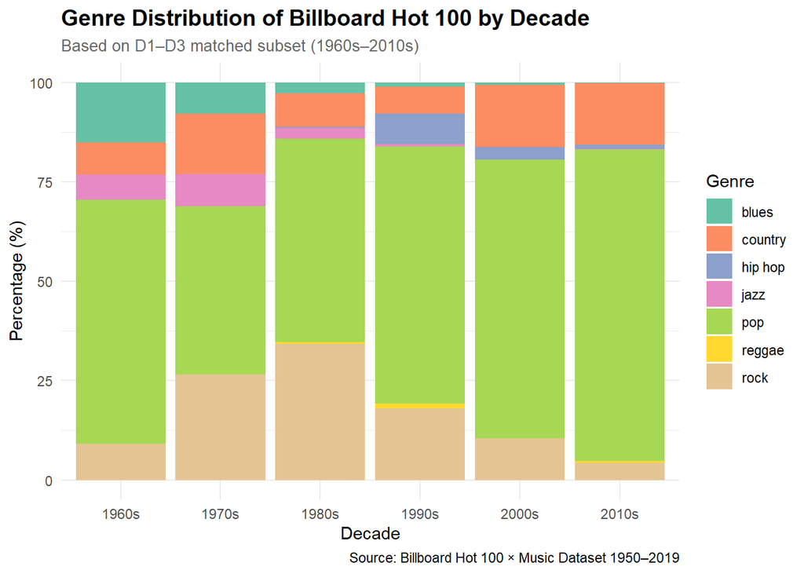

```r
# Stacked Bar Chart
genre_decade %>%
  ggplot(aes(x = decade, y = pct, fill = genre)) +
  geom_col(position = "stack") +
  scale_fill_brewer(palette = "Set2") +
  labs(
    title    = "Genre Distribution of Billboard Hot 100 by Decade",
    subtitle = "Based on D1–D3 matched subset (1960s–2010s)",
    x        = "Decade",
    y        = "Percentage (%)",
    fill     = "Genre",
    caption  = "Source: Billboard Hot 100 × Music Dataset 1950–2019"
  ) +
  theme_minimal() +
  theme(
    plot.title    = element_text(face = "bold", size = 14),
    plot.subtitle = element_text(size = 10, color = "gray40"),
    legend.position = "right"
  )
```

## Line Chart: Genre Trends over Decades

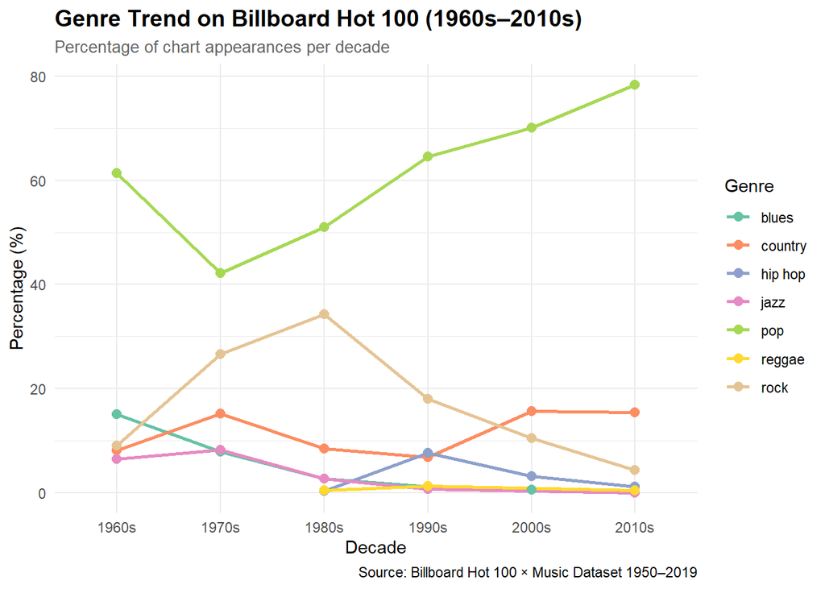

```r
# Line Chart
# Focusing on the rise and fall of Hip-Hop, Pop, and Rock
genre_decade %>%
  ggplot(aes(x = decade, y = pct, color = genre, group = genre)) +
  geom_line(linewidth = 1) +
  geom_point(size = 2.5) +
  scale_color_brewer(palette = "Set2") +
  labs(
    title    = "Genre Trend on Billboard Hot 100 (1960s–2010s)",
    subtitle = "Percentage of chart appearances per decade",
    x        = "Decade",
    y        = "Percentage (%)",
    color    = "Genre",
    caption  = "Source: Billboard Hot 100 × Music Dataset 1950–2019"
  ) +
  theme_minimal() +
  theme(
    plot.title    = element_text(face = "bold", size = 14),
    plot.subtitle = element_text(size = 10, color = "gray40"),
    legend.position = "right"
  )
```

## Summary of Observations

**Note:**

# RQ2 - How have the emotional dimensions of popular music evolved across six decades, and what cultural and technological shifts might explain these changes?

## Data preparation

```r
# Calculate average valence per year
valence_yearly <- analysis_base %>%
  group_by(year) %>%
  summarise(
    avg_valence = mean(valence, na.rm = TRUE),
    n = n()
  ) %>%
  ungroup()
```

### Calculate five setup features

```r
# Calculate annual averages for five audio features
features_yearly <- analysis_base %>%
  group_by(year) %>%
  summarise(
    valence      = mean(valence,      na.rm = TRUE),
    energy       = mean(energy,       na.rm = TRUE),
    danceability = mean(danceability, na.rm = TRUE),
    acousticness = mean(acousticness, na.rm = TRUE),
    speechiness  = mean(speechiness,  na.rm = TRUE)
  ) %>%
  pivot_longer(
    cols      = c(valence, energy, danceability, acousticness, speechiness),
    names_to  = "feature",
    values_to = "score"
  ) %>%
  mutate(
    feature = factor(feature, levels = c(
      "valence", "energy", "danceability", "acousticness", "speechiness"
    ))
  )
```

## Total emotion plot in three phases

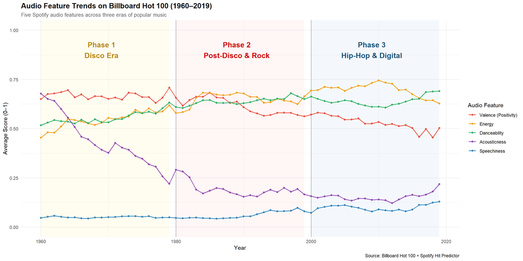

```r
ggplot(features_yearly, aes(x = year, y = score, color = feature)) +
  # Define three phases by background color
  annotate("rect",
           xmin = 1960, xmax = 1979,
           ymin = -Inf, ymax = Inf,
           fill = "#FFD700", alpha = 0.06) +
  annotate("rect",
           xmin = 1980, xmax = 1999,
           ymin = -Inf, ymax = Inf,
           fill = "#FF6B6B", alpha = 0.06) +
  annotate("rect",
           xmin = 2000, xmax = 2019,
           ymin = -Inf, ymax = Inf,
           fill = "#4A90D9", alpha = 0.06) +
  # Define three phases labels
  annotate("text",
           x = 1969, y = 0.90,
           label = "Phase 1\nDisco Era",
           size = 5, color = "#B8860B", fontface = "bold") +
  annotate("text",
           x = 1989, y = 0.90,
           label = "Phase 2\nPost-Disco & Rock",
           size = 5, color = "#CC0000", fontface = "bold") +
  annotate("text",
           x = 2009, y = 0.90,
           label = "Phase 3\nHip-Hop & Digital",
           size = 5, color = "#1A5276", fontface = "bold") +
  # Phase divider lines
  geom_vline(xintercept = 1980,
             linetype = "solid", linewidth = 0.6,
             color = "gray50", alpha = 0.5) +
  geom_vline(xintercept = 2000,
             linetype = "solid", linewidth = 0.6,
             color = "gray50", alpha = 0.5) +
  # Five trend lines
  geom_line(linewidth = 0.8, alpha = 0.85) +
  geom_point(size = 1.5, alpha = 0.85) +
  # Color settings
  scale_color_manual(
    values = c(
      "valence"      = "#E74C3C",
      "energy"       = "#F39C12",
      "danceability" = "#27AE60",
      "acousticness" = "#8E44AD",
      "speechiness"  = "#2980B9"
    ),
    labels = c(
      "valence"      = "Valence (Positivity)",
      "energy"       = "Energy",
      "danceability" = "Danceability",
      "acousticness" = "Acousticness",
      "speechiness"  = "Speechiness"
    )
  ) +
  coord_cartesian(ylim = c(0, 1)) +
  labs(
    title    = "Audio Feature Trends on Billboard Hot 100 (1960–2019)",
    subtitle = "Five Spotify audio features across three eras of popular music",
    x        = "Year",
    y        = "Average Score (0–1)",
    color    = "Audio Feature",
    caption  = "Source: Billboard Hot 100 × Spotify Hit Predictor"
  ) +
  theme_minimal() +
  theme(
    plot.title    = element_text(face = "bold", size = 14),
    plot.subtitle = element_text(size = 10, color = "gray40"),
    legend.position = "right"
  )
```

## Valence emotion plot in three phases

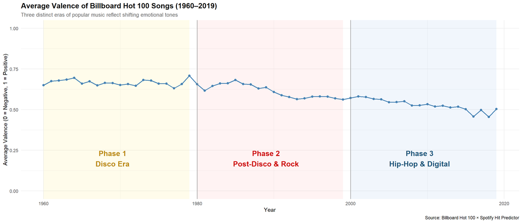

```r
ggplot(valence_yearly, aes(x = year, y = avg_valence)) +
  # Phase 1 background: Disco Era (1960–1979)
  annotate("rect",
           xmin = 1960, xmax = 1979,
           ymin = -Inf, ymax = Inf,
           fill = "#FFD700", alpha = 0.08) +
  # Phase 2 background: Post-Disco & Rock Era (1980–1999)
  annotate("rect",
           xmin = 1980, xmax = 1999,
           ymin = -Inf, ymax = Inf,
           fill = "#FF6B6B", alpha = 0.08) +
  # Phase 3 background: Hip-Hop & Digital Era (2000–2019)
  annotate("rect",
           xmin = 2000, xmax = 2019,
           ymin = -Inf, ymax = Inf,
           fill = "#4A90D9", alpha = 0.08) +
  # Phase labels
  annotate("text",
           x = 1969, y = 0.2,
           label = "Phase 1\nDisco Era",
           size = 5, color = "#B8860B", fontface = "bold") +
  annotate("text",
           x = 1989, y = 0.2,
           label = "Phase 2\nPost-Disco & Rock",
           size = 5, color = "#CC0000", fontface = "bold") +
  annotate("text",
           x = 2009, y = 0.2,
           label = "Phase 3\nHip-Hop & Digital",
           size = 5, color = "#1A5276", fontface = "bold") +
  # Trend line
  geom_line(color = "steelblue", linewidth = 0.8) +
  geom_point(color = "steelblue", size = 1.8) +
  # Force Y-axis to 0-1
  coord_cartesian(ylim = c(0, 1)) +
  # Phase divider lines
  geom_vline(xintercept = 1980,
             linetype = "solid", linewidth = 0.6,
             color = "gray50", alpha = 0.6) +
  geom_vline(xintercept = 2000,
             linetype = "solid", linewidth = 0.6,
             color = "gray50", alpha = 0.6) +
  labs(
    title    = "Average Valence of Billboard Hot 100 Songs (1960–2019)",
    subtitle = "Three distinct eras of popular music reflect shifting emotional tones",
    x        = "Year",
    y        = "Average Valence (0 = Negative, 1 = Positive)",
    caption  = "Source: Billboard Hot 100 × Spotify Hit Predictor"
  ) +
  theme_minimal() +
  theme(
    plot.title    = element_text(face = "bold", size = 14),
    plot.subtitle = element_text(size = 10, color = "gray40"),
    legend.position = "none"
  )
```

**Note**

The decline of Disco in 1979 marked the first major drop, followed by a steady fall driven by the rise of Hip-Hop and eventually accelerated by Emo Rap and social media culture in the 2010s. Historical events may have amplified the trend, but genre evolution appears to be the primary driver.

## Analysis of Valence vs. Energy Divergence

[figure not shown]

```r
# Subset: Valence and Energy only
valence_energy <- features_yearly %>%
  filter(feature %in% c("valence", "energy"))

ggplot(valence_energy, aes(x = year, y = score, color = feature)) +
  # Three-phase background shading
  annotate("rect",
           xmin = 1960, xmax = 1979,
           ymin = -Inf, ymax = Inf,
           fill = "#FFD700", alpha = 0.06) +
  annotate("rect",
           xmin = 1980, xmax = 1999,
           ymin = -Inf, ymax = Inf,
           fill = "#FF6B6B", alpha = 0.06) +
  annotate("rect",
           xmin = 2000, xmax = 2019,
           ymin = -Inf, ymax = Inf,
           fill = "#4A90D9", alpha = 0.06) +
  # Phase separators
  geom_vline(xintercept = 1980,
             linetype = "solid", linewidth = 0.6,
             color = "gray50", alpha = 0.5) +
  geom_vline(xintercept = 2000,
             linetype = "solid", linewidth = 0.6,
             color = "gray50", alpha = 0.5) +
  # Annotation for divergence
  annotate("text",
           x = 1993, y = 0.55,
           label = "Valence & Energy\nbegin to diverge",
           size = 3, color = "gray30", fontface = "italic") +
  annotate("segment",
           x = 1993, xend = 1993,
           y = 0.58, yend = 0.62,
           arrow = arrow(length = unit(0.2, "cm")),
           color = "gray30") +
  # Trend lines
  geom_line(linewidth = 1, alpha = 0.9) +
  geom_point(size = 1.8, alpha = 0.9) +
  # Colors and Labels
  scale_color_manual(
    values = c(
      "valence" = "#E74C3C",
      "energy"  = "#F39C12"
    ),
    labels = c(
      "valence" = "Valence (Positivity)",
      "energy"  = "Energy (Intensity)"
    )
  ) +
  # End-point annotations
  annotate("text",
           x = 2020, y = 0.49,
           label = "Valence\n0.49",
           size = 3, color = "#E74C3C", fontface = "bold") +
  annotate("text",
           x = 2020, y = 0.73,
           label = "Energy\n0.73",
           size = 3, color = "#F39C12", fontface = "bold") +
  labs(
    title    = "Valence vs. Energy: The Divergence of Popular Music (1960–2019)",
    subtitle = "Music has become darker in mood (↓ Valence) yet more intense in energy (↑ Energy)",
    x        = "Year",
    y        = "Average Score (0–1)",
    color    = "Audio Feature",
    caption  = "Source: Billboard Hot 100 × Spotify Hit Predictor"
  ) +
  theme_minimal() +
  theme(
    plot.title    = element_text(face = "bold", size = 14),
    plot.subtitle = element_text(size = 10, color = "gray40"),
    legend.position = "bottom"
  )
```

### Find low valence songs

```r
low_valence_songs <- analysis_base %>%
  filter(year %in% c(2016, 2018)) %>%
  distinct(song_clean, artist_clean, .keep_all = TRUE) %>%
  arrange(valence) %>%
  select(year, song_clean, artist_clean, valence, energy)

low_valence_songs %>%
  head(10) %>%
  gt() %>%
  tab_header(title = "Top 10 Lowest Valence Songs (2016&2018)") %>%
  cols_label(
    song_clean   = "Song",
    artist_clean = "Artist"
  )
```

Top 10 Lowest Valence Songs (2016&2018)

| year | Song | Artist | valence | energy |
| --- | --- | --- | --- | --- |
| 2016 | 9 | drake | 0.0379 | 0.712 |
| 2018 | topanga | trippie redd | 0.0390 | 0.615 |
| 2016 | selfish | pnb rock | 0.0399 | 0.600 |
| 2016 | forward | beyonce | 0.0498 | 0.133 |
| 2018 | delicate | taylor swift | 0.0499 | 0.404 |
| 2016 | summer sixteen | drake | 0.0541 | 0.460 |
| 2018 | biggest alley oop | quavo | 0.0548 | 0.408 |
| 2018 | stargazing | travis scott | 0.0564 | 0.789 |
| 2018 | outside today | youngboy never broke again | 0.0585 | 0.666 |
| 2016 | come and see me | partynextdoor | 0.0589 | 0.347 |

**Note**

- 2016: Drake “9”, Drake “Summer Sixteen”, Beyoncé “Forward”
- 2018: Trippie Redd “Topanga”, Travis Scott “Stargazing”, Taylor Swift “Delicate”

The two most notable valence drops in Phase 3 occurred around 2016 and 2018, coinciding with the peak influence of Emo Rap and Trap artists such as Drake, Travis Scott, and Trippie Redd whose signature dark, introspective sound directly contributed to the historic lows in musical positivity.

## Figure A: Sociopolitical Context

[figure not shown]

```r
library(tidyverse)

# Define Historical Events
events_ve <- tribble(
  ~year, ~label,                 ~color,        ~y_pos,
  1964,  "Vietnam War\nBegins",  "red",         0.730,
  1975,  "Vietnam War\nEnds",    "red",         0.695,
  1981,  "AIDS\nCrisis",         "purple",      0.730,
  1991,  "Gulf War",             "brown",       0.695,
  2001,  "9/11\nAttacks",        "darkorange",  0.730,
  2006,  "Facebook\nLaunch",     "royalblue",   0.695,
  2008,  "Financial\nCrisis",    "darkblue",    0.730,
  2008,  "Facebook\n100M Users", "royalblue",   0.660,
  2010,  "Instagram\nLaunch",    "deeppink",    0.695,
  2013,  "BLM\nMovement",        "darkgreen",   0.730,
  2016,  "U.S.\nElection",       "darkred",     0.660,
  2017,  "#MeToo\nMovement",     "hotpink",     0.695
)

# Plotting
ggplot(valence_energy, aes(x = year, y = score, color = feature)) +
  # Phase Background Shading
  annotate("rect", xmin = 1960, xmax = 1979, ymin = -Inf, ymax = Inf, fill = "#FFD700", alpha = 0.06) +
  annotate("rect", xmin = 1980, xmax = 1999, ymin = -Inf, ymax = Inf, fill = "#FF6B6B", alpha = 0.06) +
  annotate("rect", xmin = 2000, xmax = 2019, ymin = -Inf, ymax = Inf, fill = "#4A90D9", alpha = 0.06) +

  # Event Background Highlights
  annotate("rect", xmin = 2006, xmax = 2008, ymin = -Inf, ymax = Inf, fill = "royalblue", alpha = 0.07) +
  annotate("rect", xmin = 2001, xmax = 2003, ymin = -Inf, ymax = Inf, fill = "orange", alpha = 0.08) +
  annotate("rect", xmin = 1964, xmax = 1975, ymin = -Inf, ymax = Inf, fill = "red", alpha = 0.06) +
  annotate("rect", xmin = 2016, xmax = 2019, ymin = -Inf, ymax = Inf, fill = "darkred", alpha = 0.05) +

  # Vertical Lines for Historical Events
  geom_vline(data = events_ve, aes(xintercept = year),
             color = "gray60", linetype = "dashed", linewidth = 0.4, alpha = 0.6) +

  # Event Labels
  geom_text(data = events_ve, aes(x = year, y = y_pos, label = label),
            color = "gray35", size = 2.3, fontface = "bold", hjust = -0.1) +

  # Phase Separators
  geom_vline(xintercept = 1980, linetype = "solid", linewidth = 0.6, color = "gray50", alpha = 0.5) +
  geom_vline(xintercept = 2000, linetype = "solid", linewidth = 0.6, color = "gray50", alpha = 0.5) +

  # Trend Lines
  geom_line(linewidth = 1.1, alpha = 0.95) +
  geom_point(size = 1.8, alpha = 0.95) +

  # Divergence Annotation
  annotate("text", x = 1993, y = 0.63, label = "Valence & Energy\nbegin to diverge",
           size = 2.8, color = "gray30", fontface = "italic") +
  annotate("segment", x = 1993, xend = 1993, y = 0.615, yend = 0.585,
           arrow = arrow(length = unit(0.2, "cm")), color = "gray30") +

  # Custom Colors
  scale_color_manual(
    values = c("valence" = "#E74C3C", "energy" = "#F39C12"),
    labels = c("valence" = "Valence (Positivity ↓)", "energy" = "Energy (Intensity ↑)")
  ) +

  # Endpoint Value Labels
  annotate("text", x = 2020, y = 0.49, label = "Valence\n0.49", size = 3, color = "#E74C3C", fontface = "bold") +
  annotate("text", x = 2020, y = 0.73, label = "Energy\n0.73", size = 3, color = "#F39C12", fontface = "bold") +

  # Labs and Theme
  labs(
    title    = "Valence vs Energy: The Divergence of Popular Music (1960–2019)",
    subtitle = "Music became darker in mood (↓ Valence) yet more intense in energy (↑ Energy) | Key U.S. events marked",
    x        = "Year",
    y        = "Average Score (0–1)",
    color    = "Audio Feature",
    caption  = "Source: Billboard Hot 100 × Spotify Hit Predictor"
  ) +
  theme_minimal() +
  theme(
    plot.title    = element_text(face = "bold", size = 14),
    plot.subtitle = element_text(size = 9, color = "gray40"),
    legend.position = "bottom"
  )
```

## Figure B: Music Technology Evolution

[figure not shown]

```r
# ── Define Music Technology Events ──────────────────────
events_tech <- tribble(
  ~year, ~label,                         ~y_pos,
  1982,  "CD\nLaunches",                0.730,
  1999,  "Napster\nLaunches",           0.695,
  2001,  "iPod\nLaunches",              0.730,
  2003,  "iTunes\nStore Opens",         0.695,
  2008,  "Spotify\nFounded",            0.730,
  2011,  "Spotify\nEnters US",          0.695,
  2015,  "Streaming\nDominates Market", 0.730
)

ggplot(valence_energy, aes(x = year, y = score, color = feature)) +
  # Three-phase background color blocks
  annotate("rect", xmin = 1960, xmax = 1979, ymin = -Inf, ymax = Inf, fill = "#FFD700", alpha = 0.06) +
  annotate("rect", xmin = 1980, xmax = 1999, ymin = -Inf, ymax = Inf, fill = "#FF6B6B", alpha = 0.06) +
  annotate("rect", xmin = 2000, xmax = 2019, ymin = -Inf, ymax = Inf, fill = "#4A90D9", alpha = 0.06) +

  # Digital Era background (1999–2015)
  annotate("rect", xmin = 1999, xmax = 2015, ymin = -Inf, ymax = Inf, fill = "#2ECC71", alpha = 0.05) +

  # Streaming Era background (2015–2019)
  annotate("rect", xmin = 2015, xmax = 2019, ymin = -Inf, ymax = Inf, fill = "#1DB954", alpha = 0.08) +

  # Tech event vertical lines
  geom_vline(data = events_tech, aes(xintercept = year), color = "gray50", linetype = "dashed", linewidth = 0.4, alpha = 0.7) +

  # Tech event text labels
  geom_text(data = events_tech, aes(x = year, y = y_pos, label = label), color = "gray30", size = 2.3, fontface = "bold", hjust = -0.1) +

  # Phase separators
  geom_vline(xintercept = 1980, linetype = "solid", linewidth = 0.6, color = "gray50", alpha = 0.5) +
  geom_vline(xintercept = 2000, linetype = "solid", linewidth = 0.6, color = "gray50", alpha = 0.5) +

  # Main trend lines
  geom_line(linewidth = 1.1, alpha = 0.95) +
  geom_point(size = 1.8, alpha = 0.95) +

  # Divergence annotation
  annotate("text", x = 1993, y = 0.63, label = "Valence & Energy\nbegin to diverge", size = 2.8, color = "gray30", fontface = "italic") +
  annotate("segment", x = 1993, xend = 1993, y = 0.615, yend = 0.585, arrow = arrow(length = unit(0.2, "cm")), color = "gray30") +

  # Colors and Legend Labels
  scale_color_manual(
    values = c("valence" = "#E74C3C", "energy" = "#F39C12"),
    labels = c("valence" = "Valence (Positivity ↓)", "energy" = "Energy (Intensity ↑)")
  ) +

  # Endpoint score labels
  annotate("text", x = 2020, y = 0.49, label = "Valence\n0.49", size = 3, color = "#E74C3C", fontface = "bold") +
  annotate("text", x = 2020, y = 0.73, label = "Energy\n0.73", size = 3, color = "#F39C12", fontface = "bold") +

  # Era-specific labels
  annotate("text", x = 2007, y = 0.455, label = "Digital Music Era", size = 3, color = "#27AE60", fontface = "bold") +
  annotate("text", x = 2017, y = 0.455, label = "Streaming Era", size = 2.8, color = "#1DB954", fontface = "bold") +

  # Labs and Formatting
  labs(
    title    = "Valence vs Energy: The Impact of Music Consumption Technology (1960–2019)",
    subtitle = "From vinyl to streaming — how technology reshaped the emotional landscape of popular music",
    x        = "Year",
    y        = "Average Score (0–1)",
    color    = "Audio Feature",
    caption  = "Source: Billboard Hot 100 × Spotify Hit Predictor"
  ) +
  theme_minimal() +
  theme(
    plot.title    = element_text(face = "bold", size = 14),
    plot.subtitle = element_text(size = 9, color = "gray40"),
    legend.position = "bottom"
  )
```

## Comparative Table of Audio Features by Decade

```r
analysis_base %>%
  group_by(decade) %>%
  summarise(
    Valence      = round(mean(valence,      na.rm = TRUE), 3),
    Energy       = round(mean(energy,       na.rm = TRUE), 3),
    Danceability = round(mean(danceability, na.rm = TRUE), 3),
    Acousticness = round(mean(acousticness, na.rm = TRUE), 3),
    Speechiness  = round(mean(speechiness,  na.rm = TRUE), 3),
    n            = n()
  ) %>%
  gt() %>%
  tab_header(
    title    = "Summary of Average Audio Features by Decade",
    subtitle = "Aggregated trends from Billboard Hot 100 (1960s–2010s)"
  ) %>%
  cols_label(
    decade       = "Decade",
    Valence      = "Valence",
    Energy       = "Energy",
    Danceability = "Danceability",
    Acousticness = "Acousticness",
    Speechiness  = "Speechiness",
    n            = "Sample Size (n)"
  ) %>%
  fmt_number(columns = n, decimals = 0, use_seps = TRUE) %>%
  # Data coloration to highlight trends
  data_color(
    columns = c(Valence, Energy, Danceability, Acousticness, Speechiness),
    palette = "RdYlGn",
    alpha = 0.7
  ) %>%
  tab_source_note(
    source_note = "Source: Billboard Hot 100 × Spotify Dataset"
  )
```

Summary of Average Audio Features by Decade

Aggregated trends from Billboard Hot 100 (1960s–2010s)

| Decade | Valence | Energy | Danceability | Acousticness | Speechiness | Sample Size (n) |
| --- | --- | --- | --- | --- | --- | --- |
| 1960s | 0.670 | 0.514 | 0.534 | 0.533 | 0.049 | 36,826 |
| 1970s | 0.664 | 0.579 | 0.577 | 0.338 | 0.052 | 40,933 |
| 1980s | 0.651 | 0.648 | 0.627 | 0.210 | 0.046 | 44,945 |
| 1990s | 0.578 | 0.649 | 0.650 | 0.175 | 0.076 | 42,576 |
| 2000s | 0.555 | 0.708 | 0.636 | 0.149 | 0.097 | 48,301 |
| 2010s | 0.502 | 0.684 | 0.647 | 0.158 | 0.099 | 49,156 |

Source: Billboard Hot 100 × Spotify Dataset

**Key Findings: A Three-Tiered Evolution**

**1. The Darkening of Sound (Valence ↓)**

The Trend: Musical “positivity” has been in steady decline.

Data Insight: Average Valence dropped from ~0.670 in the 1960s to ~0.502 in the 2010s (a 25% decrease).

Reflection: Modern hits have moved away from the collective optimism of the past toward more somber and complex emotional landscapes.

**2. The Surge in Intensity (Energy ↑)**

The Trend: While music got “sadder,” it also got “stronger.”

Reflection: Modern music is not “sad and weak” but rather “angry and powerful.” High-intensity production (Trap, EDM) provides a sonic outlet for frustration.

**3. Structural Transformation (Danceability ↑, Speechiness ↑, Acousticness ↓)**

The Trend: A shift from acoustic instruments to rhythmic, vocal-heavy digital production.

Data Insight:

Danceability: Increased with the rise of club culture and electronic beats.

Speechiness: Surged due to the mainstream dominance of Hip-Hop.

Acousticness: Plummeted as synthesizers and 808 drums replaced traditional instrumentation.

**Final Conclusion**

Modern popular music is not simply “sadder”—it is angrier, more energetic, and more danceable, yet emotionally darker. This historic shift reflects a cultural transition from collective joy toward an individual expression of frustration, anxiety, and resilience. Popular music has evolved into a high-intensity tool for emotional catharsis in an increasingly complex world.

# RQ3 - Does the rise of speechiness in popular music reflect the mainstreaming of Hip-Hop?

```r
# Yearly Trends
speechiness_yearly <- analysis_base %>%
  group_by(year) %>%
  summarise(
    avg_speechiness = mean(speechiness, na.rm = TRUE),
    n = n()
  ) %>%
  ungroup()

# Decadal Averages
speechiness_decade <- analysis_base %>%
  group_by(decade) %>%
  summarise(
    avg_speechiness = round(mean(speechiness, na.rm = TRUE), 4),
    n = n()
  )

cat("Year Range:", min(speechiness_yearly$year),
    "–", max(speechiness_yearly$year), "\n")
```

```
Year Range: 1960 – 2019
```

## Long-term Trend of Speechiness

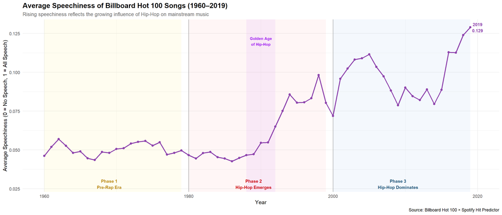

```r
ggplot(speechiness_yearly, aes(x = year, y = avg_speechiness)) +
  # Three-phase background color blocks
  annotate("rect",
           xmin = 1960, xmax = 1979,
           ymin = -Inf, ymax = Inf,
           fill = "#FFD700", alpha = 0.06) +
  annotate("rect",
           xmin = 1980, xmax = 1999,
           ymin = -Inf, ymax = Inf,
           fill = "#FF6B6B", alpha = 0.06) +
  annotate("rect",
           xmin = 2000, xmax = 2019,
           ymin = -Inf, ymax = Inf,
           fill = "#4A90D9", alpha = 0.06) +
  # Phase labels
  annotate("text",
           x = 1969, y = 0.028,
           label = "Phase 1\nPre-Rap Era",
           size = 3, color = "#B8860B", fontface = "bold") +
  annotate("text",
           x = 1989, y = 0.028,
           label = "Phase 2\nHip-Hop Emerges",
           size = 3, color = "#CC0000", fontface = "bold") +
  annotate("text",
           x = 2009, y = 0.028,
           label = "Phase 3\nHip-Hop Dominates",
           size = 3, color = "#1A5276", fontface = "bold") +
  # Key event markers
  annotate("rect",
           xmin = 1988, xmax = 1992,
           ymin = -Inf, ymax = Inf,
           fill = "purple", alpha = 0.06) +
  annotate("text",
           x = 1990, y = 0.120,
           label = "Golden Age\nof Hip-Hop",
           size = 2.8, color = "purple", fontface = "bold") +
  # Phase separators
  geom_vline(xintercept = 1980,
             linetype = "solid", linewidth = 0.6,
             color = "gray50", alpha = 0.5) +
  geom_vline(xintercept = 2000,
             linetype = "solid", linewidth = 0.6,
             color = "gray50", alpha = 0.5) +
  # Trend lines
  geom_line(color = "#8E44AD", linewidth = 0.9) +
  geom_point(color = "#8E44AD", size = 1.8) +
  # Endpoint labels
  annotate("text",
           x = 2020, y = speechiness_yearly %>%
             filter(year == 2019) %>% pull(avg_speechiness),
           label = paste0("2019\n",
             round(speechiness_yearly %>%
               filter(year == 2019) %>%
               pull(avg_speechiness), 3)),
           size = 3, color = "#8E44AD", fontface = "bold") +
  labs(
    title    = "Average Speechiness of Billboard Hot 100 Songs (1960–2019)",
    subtitle = "Rising speechiness reflects the growing influence of Hip-Hop on mainstream music",
    x        = "Year",
    y        = "Average Speechiness (0 = No Speech, 1 = All Speech)",
    caption  = "Source: Billboard Hot 100 × Spotify Hit Predictor"
  ) +
  theme_minimal() +
  theme(
    plot.title    = element_text(face = "bold", size = 14),
    plot.subtitle = element_text(size = 10, color = "gray40")
  )
```

## Decadal Comparison of Speechiness

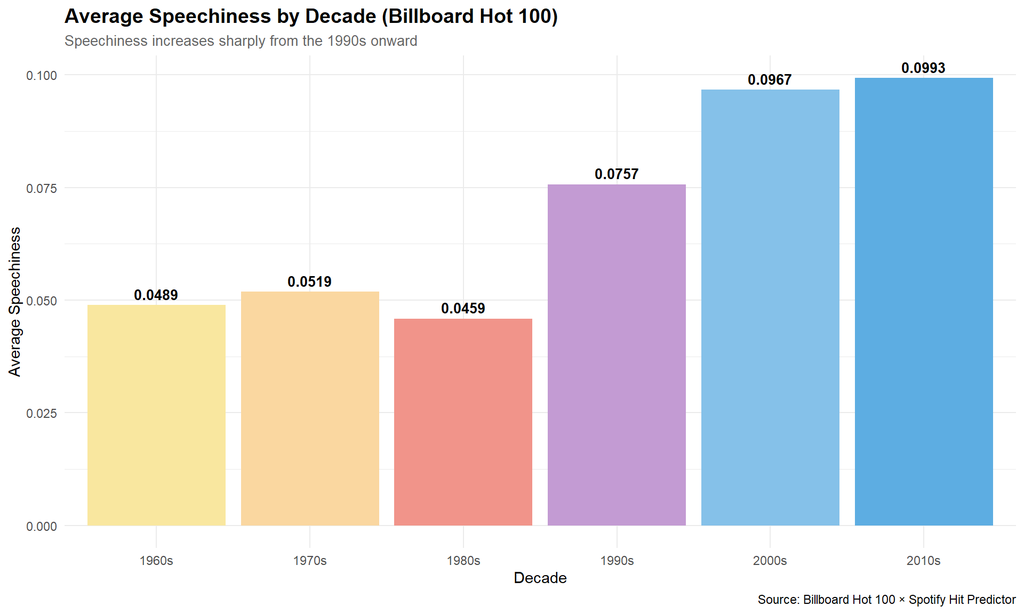

```r
speechiness_decade %>%
  ggplot(aes(x = decade, y = avg_speechiness, fill = decade)) +
  geom_col(show.legend = FALSE) +
  geom_text(aes(label = avg_speechiness),
            vjust = -0.5, size = 3.5, fontface = "bold") +
  scale_fill_manual(values = c(
    "1960s" = "#F9E79F",
    "1970s" = "#FAD7A0",
    "1980s" = "#F1948A",
    "1990s" = "#C39BD3",
    "2000s" = "#85C1E9",
    "2010s" = "#5DADE2"
  )) +
  labs(
    title    = "Average Speechiness by Decade (Billboard Hot 100)",
    subtitle = "Speechiness increases sharply from the 1990s onward",
    x        = "Decade",
    y        = "Average Speechiness",
    caption  = "Source: Billboard Hot 100 × Spotify Hit Predictor"
  ) +
  theme_minimal() +
  theme(
    plot.title    = element_text(face = "bold", size = 14),
    plot.subtitle = element_text(size = 10, color = "gray40")
  )
```

## Speechiness Comparison by Genre

```r
# Analysis based on D3 subset
genre_speech <- analysis_base %>%
  filter(!is.na(genre)) %>%
  group_by(genre) %>%
  summarise(
    avg_speechiness = round(mean(speechiness, na.rm = TRUE), 4),
    n = n()
  ) %>%
  arrange(desc(avg_speechiness))

cat("Average Speechiness per Genre:\n")
```

```
Average Speechiness per Genre:
```

```r
genre_speech %>%
  gt() %>%
  tab_header(title = "Speechiness by Genre") %>%
  fmt_number(columns = n, decimals = 0, use_seps = TRUE) %>%
  data_color(
    columns = avg_speechiness,
    palette = "Purples"
  )
```

Speechiness by Genre

| genre | avg_speechiness | n |
| --- | --- | --- |
| hip hop | 0.2325 | 895 |
| reggae | 0.1402 | 159 |
| pop | 0.0690 | 27,700 |
| rock | 0.0480 | 7,528 |
| blues | 0.0474 | 1,644 |
| jazz | 0.0461 | 1,115 |
| country | 0.0371 | 5,323 |

## Genre Speechiness Bar Chart

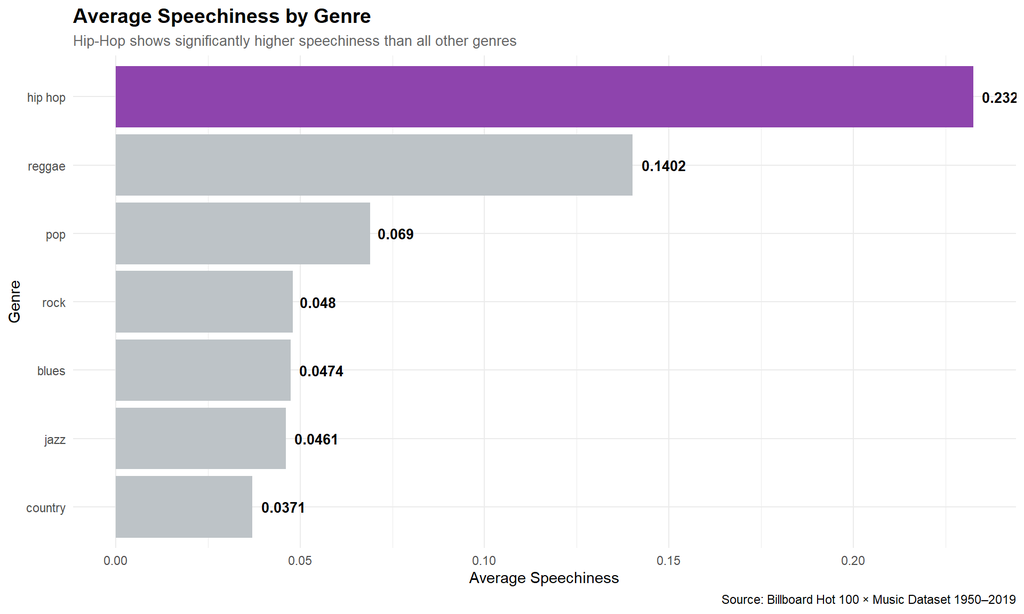

```r
# Genre Speechiness Bar Chart
genre_speech %>%
  mutate(
    genre = fct_reorder(genre, avg_speechiness),
    is_hiphop = genre == "hip hop"
  ) %>%
  ggplot(aes(x = genre, y = avg_speechiness,
             fill = is_hiphop)) +
  geom_col(show.legend = FALSE) +
  geom_text(aes(label = avg_speechiness),
            hjust = -0.2, size = 3.5, fontface = "bold") +
  scale_fill_manual(values = c(
    "TRUE"  = "#8E44AD",
    "FALSE" = "#BDC3C7"
  )) +
  coord_flip() +
  labs(
    title    = "Average Speechiness by Genre",
    subtitle = "Hip-Hop shows significantly higher speechiness than all other genres",
    x        = "Genre",
    y        = "Average Speechiness",
    caption  = "Source: Billboard Hot 100 × Music Dataset 1950–2019"
  ) +
  theme_minimal() +
  theme(
    plot.title    = element_text(face = "bold", size = 14),
    plot.subtitle = element_text(size = 10, color = "gray40")
  )
```